# hwk_9

Holden Jones

2025-04-24

```r
library(tidyverse)
```

```r
library(ggplot2)
library(MuMIn)

dinos <- read_csv('data/dinos.csv')
```

#1.

Ask following questions - How fast does dino grow when it is young and growing quickly? - Any evidence that this curve saturates at some asymptotic mass? - Or is the curve basically exponential? - If there is a sigmoidal relationship, what is estimated maximum size? - How well does simple linear model fit relative to more realistic models?

start by plotting data - interesting, certainly seems like this data could be either exp or sigmoidal - depending on how much value we place on top age data points

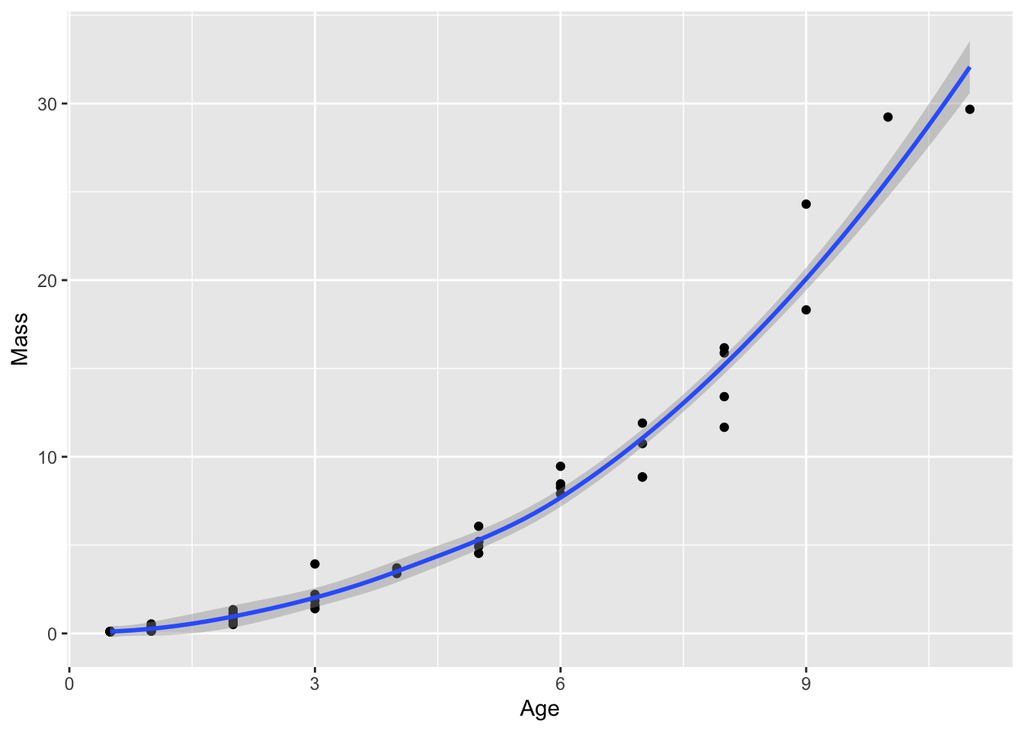

```r
ggplot(data = dinos, aes(x = Age, y = Mass)) +
  geom_point() +
  geom_smooth(method = "loess")
```

To answer, need to fit three curves to dataset using nls() - linear model - exponential model - logistic model

```r
mod_lin = nls(Mass ~ a + b*Age, data = dinos,
start = list(a = 0.01, b = 1/2)
)

mod_exp = nls(Mass ~ a*exp(r*Age), data = dinos,
start = list(a = 0.01, r = 5/4)
)

mod_log = nls(Mass ~ (m) / (1 + exp(-r*(Age - n))), data = dinos,
start = list(r = 5/4, m = 30, n = 5/4)
)
```

- need to supply start values for parameters, may be tricky
  - if get errors, try other values
  - for each model, report coefficient estimates and confidence intervals, and plot fitted curves on top of raw data

coefficient estimates

```r
summary(mod_lin) # a = -1.87, b = 2.07
```

```
##
## Formula: Mass ~ a + b * Age
##
## Parameters:
##   Estimate Std. Error t value Pr(>|t|)
## a -1.86634    0.36948  -5.051 2.82e-06 ***
## b  2.07211    0.09394  22.057  < 2e-16 ***
## ---
## Signif. codes:  0 '***' 0.001 '**' 0.01 '*' 0.05 '.' 0.1 ' ' 1
##
## Residual standard error: 2.432 on 78 degrees of freedom
##
## Number of iterations to convergence: 1
## Achieved convergence tolerance: 9.698e-07
```

```r
summary(mod_exp) # a = .98, r = .33
```

```
##
## Formula: Mass ~ a * exp(r * Age)
##
## Parameters:
##   Estimate Std. Error t value Pr(>|t|)
## a  0.97643    0.09734   10.03  1.1e-15 ***
## r  0.32767    0.01088   30.11  < 2e-16 ***
## ---
## Signif. codes:  0 '***' 0.001 '**' 0.01 '*' 0.05 '.' 0.1 ' ' 1
##
## Residual standard error: 1.519 on 78 degrees of freedom
##
## Number of iterations to convergence: 16
## Achieved convergence tolerance: 5.523e-06
```

```r
summary(mod_log) # r = .51, m = 42.99, n = 9.13
```

```
##
## Formula: Mass ~ (m)/(1 + exp(-r * (Age - n)))
##
## Parameters:
##   Estimate Std. Error t value Pr(>|t|)
## r  0.51254    0.02854   17.96   <2e-16 ***
## m 42.99215    3.67703   11.69   <2e-16 ***
## n  9.12512    0.35587   25.64   <2e-16 ***
## ---
## Signif. codes:  0 '***' 0.001 '**' 0.01 '*' 0.05 '.' 0.1 ' ' 1
##
## Residual standard error: 1.04 on 77 degrees of freedom
##
## Number of iterations to convergence: 16
## Achieved convergence tolerance: 3.728e-06
```

plots

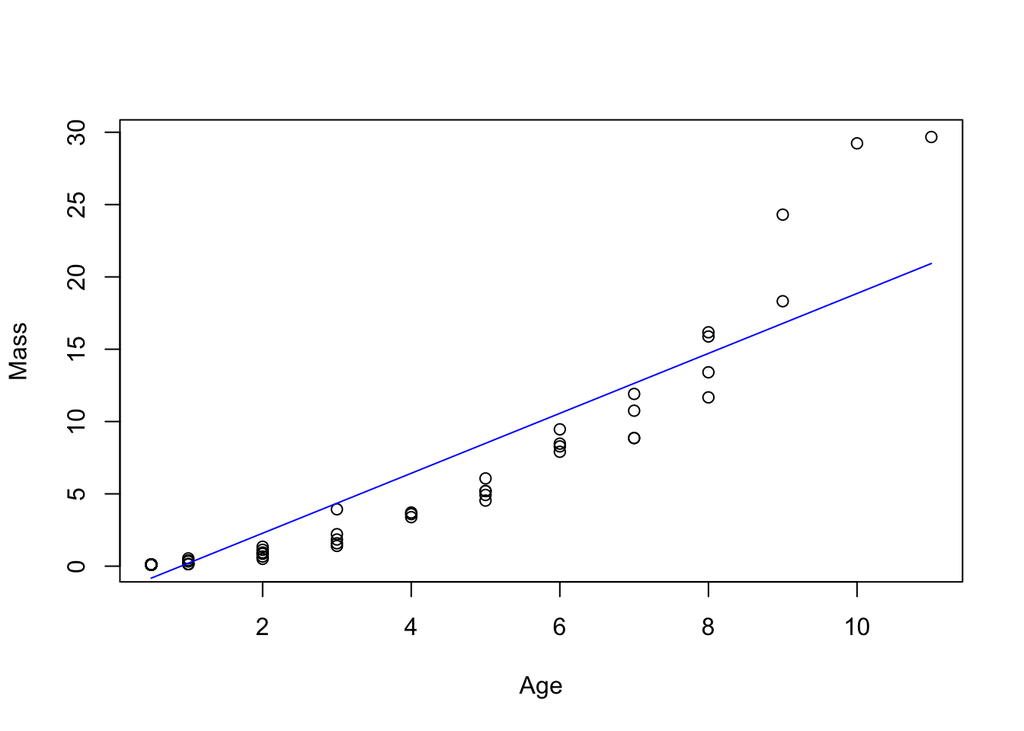

```r
plot(Mass ~ Age, data = dinos)
lines(dinos$Age, predict(mod_lin), col = "blue")
```

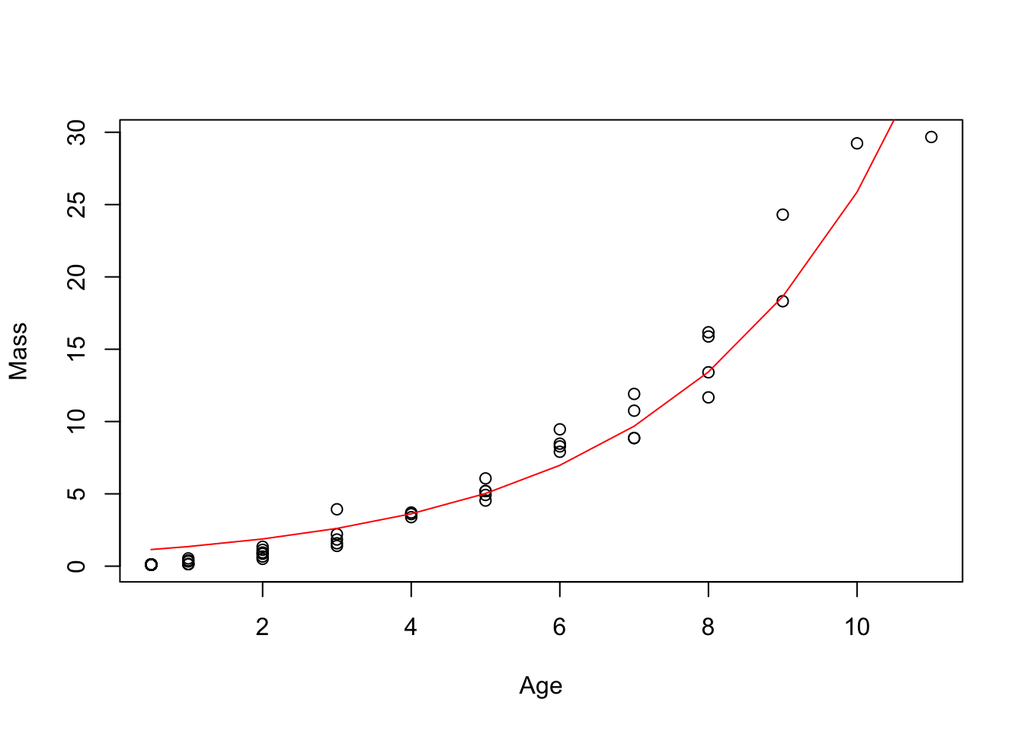

```r
plot(Mass ~ Age, data = dinos)
lines(dinos$Age, predict(mod_exp), col = "red")
```

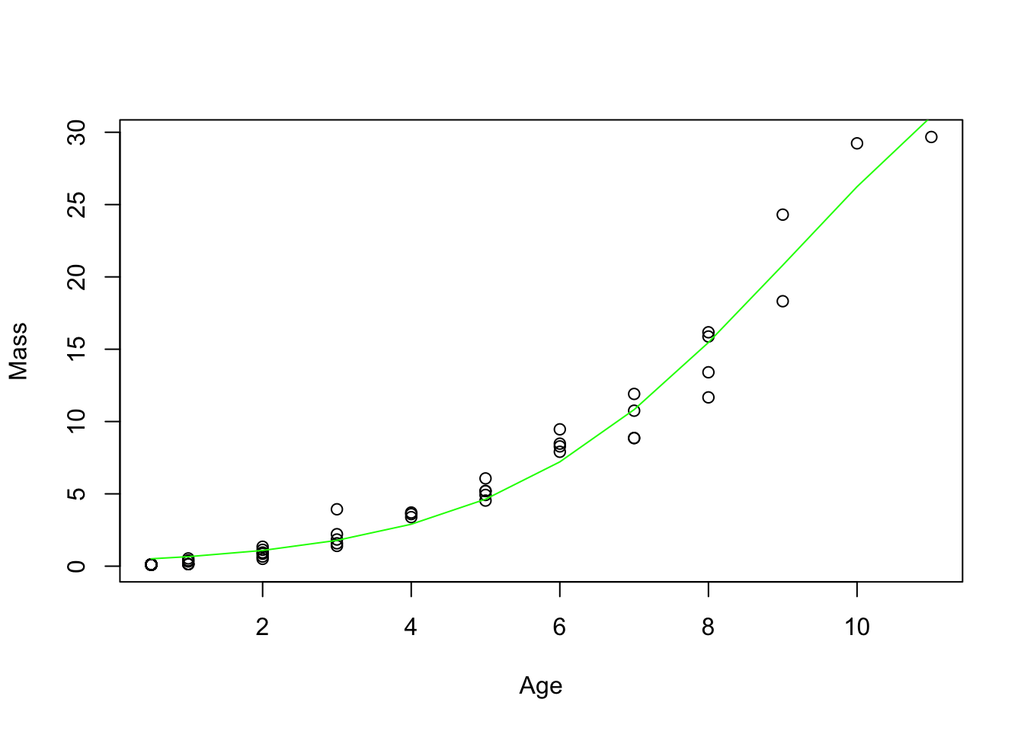

```r
plot(Mass ~ Age, data = dinos)
lines(dinos$Age, predict(mod_log), col = "green")
```

#2.

Compare three models using AICc - Which model is best? - What are AICc values and Akaike weights for three models? - How to interpret these results in terms of relative support for each model?

AICc

```r
AICc(mod_lin) # 373.54
```

```
## [1] 373.5375
```

```r
AICc(mod_exp) # 298.17
```

```
## [1] 298.1695
```

```r
AICc(mod_log) # 238.73
```

```
## [1] 238.7308
```

AICc suggests that the logistic model is a far better fit than the other two

weights

```r
#use delta-AIC to calculate the model likelihoods for all comparisons
model.like.1 = exp(-0.5*(AICc(mod_lin) - AICc(mod_exp)))
model.like.2 = exp(-0.5*(AICc(mod_exp) - AICc(mod_log)))
model.like.3 = exp(-0.5*(AICc(mod_log) - AICc(mod_log)))
#sum the model likelihoods for standardization
summed.likes = sum(c(model.like.1, model.like.2, model.like.3))
#calculate the Akaike weights
weight1 = model.like.1/summed.likes
weight2 = model.like.2/summed.likes
weight3 = model.like.3/summed.likes

weight1 # basically 0
```

```
## [1] 4.305685e-17
```

```r
weight2 # basically 0
```

```
## [1] 1.238953e-13
```

```r
weight3 # 1
```

```
## [1] 1
```

comparing model weights also suggests that the logistic model is a far better fit than the other two

The logistic model is the winner! So yes, seems like there’s a max.

#3.

What is estimated exponential growth rate (r) for exponential and logistic models? - What is confidence interval on this parameter for the two models? - For exponential growth, doubling time is log(2)/r. How long does it take dino to double in size, based on two models

```r
# r confidence intervals
confint(mod_exp) # r 2.5%: .31 - 97.5%: .35
```

```
##        2.5%     97.5%
## a 0.8108754 1.1592835
## r 0.3088246 0.3475626
```

```r
confint(mod_log) # r 2.5%: .46 - 97.5%: .57
```

```
##         2.5%      97.5%
## r  0.4639475  0.5668192
## m 37.2608575 51.4490029
## n  8.5454205  9.8756227
```

```r
# doubling time
r_list = c(.31, .35, .46, .57)

for (r in r_list) {
  print(log(2)/r)
}
```

```
## [1] 2.235959
## [1] 1.980421
## [1] 1.506842
## [1] 1.216048
```

confidence intervals - interesting, there’s no overlap in r confidence intervals for the exp and log models. Exp estimates that r is between .31 - .35, while log estimates that r is between .46 - .57

doubling time - our estimate of doubling time depends on which model we’re pulling our r paramter estimate from. Using r from the exp model estimates between 1.98 - 2.24 years doubling time for these critters, while r from the log model estimates between 1.22 - 1.51 years doubling time.

#4.

Is there evidence dino has a maximum size? - Yes! Logistic model which includes a max estimate is by far the best fitting model

```r
summary(mod_log) # m estimate 42.99
```

```
##
## Formula: Mass ~ (m)/(1 + exp(-r * (Age - n)))
##
## Parameters:
##   Estimate Std. Error t value Pr(>|t|)
## r  0.51254    0.02854   17.96   <2e-16 ***
## m 42.99215    3.67703   11.69   <2e-16 ***
## n  9.12512    0.35587   25.64   <2e-16 ***
## ---
## Signif. codes:  0 '***' 0.001 '**' 0.01 '*' 0.05 '.' 0.1 ' ' 1
##
## Residual standard error: 1.04 on 77 degrees of freedom
##
## Number of iterations to convergence: 16
## Achieved convergence tolerance: 3.728e-06
```

```r
confint(mod_log) # 2.5% 37.26 - 97.5% 51.45
```

```
##         2.5%      97.5%
## r  0.4639475  0.5668192
## m 37.2608575 51.4490029
## n  8.5454205  9.8756227
```

```r
dinos %>%
arrange(desc(Mass))
```

```
## # A tibble: 80 × 2
##      Age  Mass
##    <dbl> <dbl>
##  1    11  29.7
##  2    10  29.2
##  3     9  24.3
##  4     9  18.3
##  5     8  16.2
##  6     8  15.9
##  7     8  13.4
##  8     7  11.9
##  9     8  11.7
## 10     7  10.7
## # ℹ 70 more rows
```

- How much stock do we put in Max estimate given data we have? If max is true, how big does this dino get, relative to human? I don’t put too much stock in the max estimate from the log model b/c we have 80 obs and none approach the estimate. If max is true this is about 1/14th the max recorded weight of a human (according to google). But this dino appears to max out (according to our log model) at a little under 1/2 the weight of the average human male.

#5.

Compare three models using LOOCV

```r
# for linear model
errors = vector()
for(i in 1:nrow(dinos)) {
  datause = dinos[-i,]
  linear_model <- nls(Mass ~ a + b*Age, data = datause,
    start = list(a = 0.01, b = 1/2))
  errors[i] = dinos$Mass[i] - predict(linear_model, data.frame(Age = dinos$Age[i]))
}
cv1 = sqrt(mean(errors^2))

cv1 # 2.57
```

```
## [1] 2.566121
```

```r
# for exponential model
errors = vector()
for(i in 1:nrow(dinos)) {
  datause = dinos[-i,]
  exponential_model <- nls(Mass ~ a * exp(r * Age), data = datause,
                 start = list(a = 0.01, r = 5/4))
  errors[i] = dinos$Mass[i] - predict(exponential_model, data.frame(Age = dinos$Age[i]))
}
cv2 = sqrt(mean(errors^2))

cv2 # 2.20
```

```
## [1] 2.20483
```

```r
# for logistic model - interesting, didn't converge on values used above
errors = vector()
for(i in 1:nrow(dinos)) {
  datause = dinos[-i,]
  logistic_model <- nls(Mass ~ Mmax / (1 + exp(-r * (Age - Age0))),
                      data = datause,
                      start = list(Mmax = 29, r = 1, Age0 = 6))
  errors[i] = dinos$Mass[i] - predict(logistic_model, data.frame(Age = dinos$Age[i]))
}
cv3 = sqrt(mean(errors^2))

cv3 # 1.33
```

```
## [1] 1.3256
```

- Which model is best at predicting data, in terms of LOOCV? again it is the logistic model that is the best at predicting data
- What is typical difference b/ween predicted values and observed values for best model? square root of mean squared errors is 1.33 for the best model, so this is a ‘typical’ difference between predicted and observed values
- Does LOOCV yield same ranking of models as AIC? yes it does! this lends lots of support for the notion that the logistic model is the best at modeling the age and size relationship of these dinos, even if we’d like some refinement with the max size estimate